# Regularization in linear regression

Jose M Sallan

10/04/2020

# 1 Insurance data

To illustrate the concepts of this document, we will use the same data of the introduction to regression analysis.

## 1.1 The dataset

`InsuranceCharges` contains several features of individuals such as age, physical/family condition and location, and their existing medical expense. We intend to predict future medical expenses of individuals that help medical insurance to make decision on charging the premium.

The source of data is this Kaggle competition:

https://www.kaggle.com/noordeen/insurance-premium-prediction

The data are embedded in the `BAdatasets` package. We’ll load also `tidyverse` for data wrangling and plotting and `caret` for machine learning.

```r
library(tidyverse)
library(BAdatasets)
library(caret)
```

We rename the dataset as `insurance` and introduce the categorical variable `bmi30` characterizing obesity.

```r
insurance <- InsuranceCharges
insurance <- insurance %>% mutate(bmi30 = as.factor(ifelse(insurance$bmi >= 30, 1, 0)))
```

## 1.2 The linear regression model

Let’s split data into train and test…

```r
set.seed(1111)
inTrain <- createDataPartition(insurance$charges, p=0.8, list=FALSE)
insurance_train <- insurance[inTrain, ]
insurance_test <- insurance[-inTrain, ]
```

…and define a regression model as an starting point:

```r
mod05 <- train(charges ~ poly(age, 2) + children + smoker  + region + bmi30*smoker, method="lm", insurance_train, preProcess=c("center", "scale"))
pr_train05 <- predict(mod05, insurance_train)
postResample(pred = pr_train05, insurance_train$charges)
```

```
##         RMSE     Rsquared          MAE
## 4241.1986634    0.8752473 2309.9894874
```

The prediction on the test set does not show overfitting:

```r
pr_test05 <- predict(mod05, insurance_test)
postResample(pred = pr_test05, insurance_test$charges)
```

```
##         RMSE     Rsquared          MAE
## 5243.2589035    0.8251355 2723.0136765
```

In datasets with many features, it can happen that using all of them leads to a worse performance than using only a subset. Selecting the features to introduce for better accuracy is the **feature selection** problem. There are two *classical* techniques of feature selection:

- **Best subsets**, which examines the fit of all possible subsets of features to choose the best subset. This can be computationally expensive, and sometimes we use algorithms like simulated annealing to choose that subset.
- **Stepwise regression**, consisting in adding or removing a feature in each step, until a satisfactory model is found.

An alternative to these strategies is **regularization**, in which we limit the total value of regression coefficients.

# 2 Regularization in linear regression

The regression coefficients in the ordinary least squares (OLS) approach to linear regression are the ones that minimize the sum of squared errors:

$$\displaystyle\sum_{i=1}^n \left( y_i - \hat{y}_i \right)^2$$

Let’s examine two regularization approaches to OLS, lasso and ridge regression.

## 2.1 L1 regularization: lasso regression

The name **lasso** stands for **least absolute shrinkage and selection operator**.

Lasso was introduced in order to improve the prediction accuracy and interpretability of regression models by altering the model fitting process. We select only a subset of the provided covariates for use in the final model, rather than using all of them.

The approach of lasso is to force regression coefficients to shrink, forcing that the sum of absolute values or 1-norm to be smaller than a value $t$:

$$\displaystyle\sum_{j=1}^p |\beta_j| = \lVert \beta \lVert_1 \leq t$$

This is equivalent to minimizing:

$$\displaystyle\sum_{i=1}^n \left( y_i - \hat{y}_i \right)^2 + \lambda \lVert \beta \lVert_1$$

where $\lambda$ is a parameter to be estimated from data.

This approach may force some regression coefficients to be set to zero, choosing a simpler model that does not include those coefficients. As it uses the 1-norm of regression coefficients, lasso is also called **L1 regularization**.

## 2.2 L2 regularization: ridge regression

Ridge regression uses a strategy analogous to lasso regression, but bounding the 2-norm of the vector of regression coefficients to a value $t$:

$$\sqrt{\displaystyle\sum_{j=1}^p \beta_j^2} = \lVert \beta \lVert_2 \leq t$$

This is equivalent to minimizing:

$$\displaystyle\sum_{i=1}^n \left( y_i - \hat{y}_i \right)^2 + \lambda \lVert \beta \lVert_2$$

The parameter $\lambda$ has to be estimated from data. As ridge regression uses the 2-norm, we call it **L2 regularization**.

Although the formula of ridge regression is quite similar to lasso, ridge regression improves prediction error by shrinking large regression coefficients in order to reduce overfitting.

## 2.3 R implementation

Lasso and ridge regularizations are implemented in R through the `glmnet` package. This package allows performing L1 and L2 regularization, obtaining coefficients by minimizing:

$$\displaystyle\sum_{i=1}^n \left( y_i - \hat{y}_i \right)^2 + \lambda \left( \alpha \lVert \beta \lVert_1 + \left( 1- \alpha \right)\lVert \beta \lVert_2 \right)$$

You can get more information about `glmnet` on:

https://web.stanford.edu/~hastie/Papers/Glmnet_Vignette.pdf

To use adequately regularization, it is important to **standardize (center and scale)** feature values.

# 3 Lasso and ridge regression with `glmnet`

We will use `caret` to look for the best combination of parameter values for regularization. We define the following tuning grid:

```r
L1L2grid <- expand.grid(alpha=c(0, 0.5, 1), lambda=c(0, 1, 5, 10, 20, 30))
```

Here we are tring L1 and L2 regularization, and a compromise between both. The values of $\lambda$ have been set from a initial exploration of the model.

Let’s train the model with regularization:

```r
mod06 <- train(charges ~ age + I(age^2) + sex + children + region + bmi30*smoker, insurance_train, method="glmnet", trControl=trainControl(method='repeatedcv', number=5, repeats=3), preProcess=c("center", "scale"), tuneGrid=L1L2grid)
```

Let’s see the results:

```r
mod06
```

```
## glmnet
##
## 1072 samples
##    6 predictor
##
## Pre-processing: centered (10), scaled (10)
## Resampling: Cross-Validated (5 fold, repeated 3 times)
## Summary of sample sizes: 858, 857, 859, 856, 858, 857, ...
## Resampling results across tuning parameters:
##
##   alpha  lambda  RMSE      Rsquared   MAE
##   0.0     0      4298.351  0.8724318  2476.399
##   0.0     1      4298.351  0.8724318  2476.399
##   0.0     5      4298.351  0.8724318  2476.399
##   0.0    10      4298.351  0.8724318  2476.399
##   0.0    20      4298.351  0.8724318  2476.399
##   0.0    30      4298.351  0.8724318  2476.399
##   0.5     0      4262.856  0.8726119  2344.215
##   0.5     1      4262.856  0.8726119  2344.215
##   0.5     5      4262.856  0.8726119  2344.215
##   0.5    10      4262.856  0.8726119  2344.215
##   0.5    20      4262.856  0.8726119  2344.215
##   0.5    30      4262.831  0.8726136  2344.248
##   1.0     0      4261.820  0.8726672  2342.619
##   1.0     1      4261.820  0.8726672  2342.619
##   1.0     5      4261.820  0.8726672  2342.619
##   1.0    10      4261.820  0.8726672  2342.619
##   1.0    20      4261.833  0.8726691  2342.812
##   1.0    30      4262.755  0.8726204  2345.665
##
## RMSE was used to select the optimal model using the smallest value.
## The final values used for the model were alpha = 1 and lambda = 10.
```

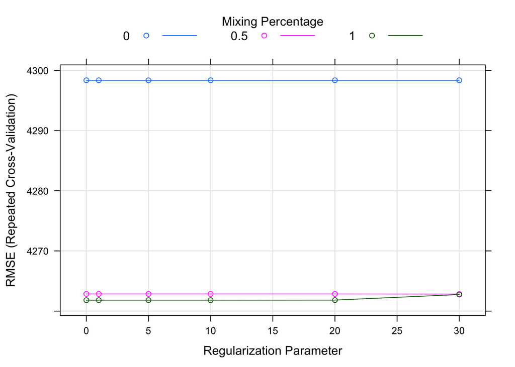

```r
plot(mod06)
```

We can see that the best performance is obtained with L1 regularization, and that $\lambda$ is not so important to obtain accuracy in this model.

Let’s obtain the predictions for the train and test sets for this model.

```r
pr_train06 <- predict(mod06, insurance_train)
pr_test06 <- predict(mod06, insurance_test)

postResample(pred = pr_train06, insurance_train$charges)
```

```
##         RMSE     Rsquared          MAE
## 4235.5025201    0.8755885 2315.7651971
```

We can compare the performance of original and regularized models on the train set:

```r
postResample(pred = pr_train05, insurance_train$charges)
```

```
##         RMSE     Rsquared          MAE
## 4241.1986634    0.8752473 2309.9894874
```

```r
postResample(pred = pr_train06, insurance_train$charges)
```

```
##         RMSE     Rsquared          MAE
## 4235.5025201    0.8755885 2315.7651971
```

and in the test set:

```r
postResample(pred = pr_test05, insurance_test$charges)
```

```
##         RMSE     Rsquared          MAE
## 5243.2589035    0.8251355 2723.0136765
```

```r
postResample(pred = pr_test06, insurance_test$charges)
```

```
##         RMSE     Rsquared          MAE
## 5232.3505362    0.8259827 2710.1805891
```

The effect of regularization is quite insignificant here. Note that the number of predictors of this model is small, and that all of them are significant when predicting the outcome.